# 五王之战分析 - 冰与火之歌

```python
clean.head(38)
```

|  | name | year | battle_number | attacker_king | defender_king | attacker_outcome | battle_type | location |
| --- | --- | --- | --- | --- | --- | --- | --- | --- |
| 0 | Battle of the Golden Tooth | 298 | 1 | Joffrey/Tommen Baratheon | Robb Stark | win | pitched battle | Golden Tooth |
| 1 | Battle at the Mummer's Ford | 298 | 2 | Joffrey/Tommen Baratheon | Robb Stark | win | ambush | Mummer's Ford |
| 2 | Battle of Riverrun | 298 | 3 | Joffrey/Tommen Baratheon | Robb Stark | win | pitched battle | Riverrun |
| 3 | Battle of the Green Fork | 298 | 4 | Robb Stark | Joffrey/Tommen Baratheon | loss | pitched battle | Green Fork |
| 4 | Battle of the Whispering Wood | 298 | 5 | Robb Stark | Joffrey/Tommen Baratheon | win | ambush | Whispering Wood |
| 5 | Battle of the Camps | 298 | 6 | Robb Stark | Joffrey/Tommen Baratheon | win | ambush | Riverrun |
| 6 | Sack of Darry | 298 | 7 | Joffrey/Tommen Baratheon | Robb Stark | win | pitched battle | Darry |
| 7 | Battle of Moat Cailin | 299 | 8 | Balon/Euron Greyjoy | Robb Stark | win | pitched battle | Moat Cailin |
| 8 | Battle of Deepwood Motte | 299 | 9 | Balon/Euron Greyjoy | Robb Stark | win | siege | Deepwood Motte |
| 9 | Battle of the Stony Shore | 299 | 10 | Balon/Euron Greyjoy | Robb Stark | win | ambush | Stony Shore |
| 10 | Battle of Torrhen's Square | 299 | 11 | Robb Stark | Balon/Euron Greyjoy | win | pitched battle | Torrhen's Square |
| 11 | Battle of Winterfell | 299 | 12 | Balon/Euron Greyjoy | Robb Stark | win | ambush | Winterfell |
| 12 | Sack of Torrhen's Square | 299 | 13 | Balon/Euron Greyjoy | Balon/Euron Greyjoy | win | siege | Torrhen's Square |
| 13 | Sack of Winterfell | 299 | 14 | Joffrey/Tommen Baratheon | Robb Stark | win | ambush | Winterfell |
| 14 | Battle of Oxcross | 299 | 15 | Robb Stark | Joffrey/Tommen Baratheon | win | ambush | Oxcross |
| 15 | Siege of Storm's End | 299 | 16 | Stannis Baratheon | Renly Baratheon | win | siege | Storm's End |
| 16 | Battle of the Fords | 299 | 17 | Joffrey/Tommen Baratheon | Robb Stark | loss | pitched battle | Red Fork |
| 17 | Sack of Harrenhal | 299 | 18 | Robb Stark | Joffrey/Tommen Baratheon | win | ambush | Harrenhal |
| 18 | Battle of the Crag | 299 | 19 | Robb Stark | Joffrey/Tommen Baratheon | win | ambush | Crag |
| 19 | Battle of the Blackwater | 299 | 20 | Stannis Baratheon | Joffrey/Tommen Baratheon | loss | pitched battle | King's Landing |
| 20 | Siege of Darry | 299 | 21 | Robb Stark | Joffrey/Tommen Baratheon | win | siege | Darry |
| 21 | Battle of Duskendale | 299 | 22 | Robb Stark | Joffrey/Tommen Baratheon | loss | pitched battle | Duskendale |
| 22 | Battle of the Burning Septry | 299 | 23 | NaN | NaN | win | pitched battle | NaN |
| 23 | Battle of the Ruby Ford | 299 | 24 | Joffrey/Tommen Baratheon | Robb Stark | win | pitched battle | Ruby Ford |
| 24 | Retaking of Harrenhal | 299 | 25 | Joffrey/Tommen Baratheon | NaN | win | pitched battle | Harrenhal |
| 25 | The Red Wedding | 299 | 26 | Joffrey/Tommen Baratheon | Robb Stark | win | ambush | The Twins |
| 26 | Siege of Seagard | 299 | 27 | Robb Stark | Joffrey/Tommen Baratheon | win | siege | Seagard |
| 27 | Battle of Castle Black | 300 | 28 | Stannis Baratheon | Mance Rayder | loss | siege | Castle Black |
| 28 | Fall of Moat Cailin | 300 | 29 | Joffrey/Tommen Baratheon | Balon/Euron Greyjoy | win | siege | Moat Cailin |
| 29 | Sack of Saltpans | 300 | 30 | NaN | NaN | win | razing | Saltpans |
| 30 | Retaking of Deepwood Motte | 300 | 31 | Stannis Baratheon | Balon/Euron Greyjoy | win | pitched battle | Deepwood Motte |
| 31 | Battle of the Shield Islands | 300 | 32 | Balon/Euron Greyjoy | Joffrey/Tommen Baratheon | win | pitched battle | Shield Islands |
| 32 | Invasion of Ryamsport, Vinetown, and Starfish ... | 300 | 33 | Balon/Euron Greyjoy | Joffrey/Tommen Baratheon | win | razing | Ryamsport, Vinetown, Starfish Harbor |
| 33 | Second Seige of Storm's End | 300 | 34 | Joffrey/Tommen Baratheon | Stannis Baratheon | win | siege | Storm's End |
| 34 | Siege of Dragonstone | 300 | 35 | Joffrey/Tommen Baratheon | Stannis Baratheon | win | siege | Dragonstone |
| 35 | Siege of Riverrun | 300 | 36 | Joffrey/Tommen Baratheon | Robb Stark | win | siege | Riverrun |
| 36 | Siege of Raventree | 300 | 37 | Joffrey/Tommen Baratheon | Robb Stark | win | siege | Raventree |
| 37 | Siege of Winterfell | 300 | 38 | Stannis Baratheon | Joffrey/Tommen Baratheon | NaN | NaN | Winterfell |

```python
clean = clean.dropna()
```

```python
clean.info()
```

[output not shown]

```python
clean.to_csv('battles_edited.csv',index=False)
```

```python
# 更换index值
clean = pd.read_csv('battles_edited.csv', index_col='name')
```

```python
# 添加新列win_king记录每场战争胜利的国王
frame = pd.DataFrame(clean, columns = ['attacker_king', 'defender_king', 'attacker_outcome'])
def function(a, b, outcome):
    if outcome == "win":
        return a
    else:
        return b
clean['winner_king'] = frame.apply(lambda x: function(x.attacker_king, x.defender_king, x.attacker_outcome), axis = 1)

clean.head(34)
```

| name | year | battle_number | attacker_king | defender_king | attacker_outcome | battle_type | location | winner_king |
| --- | --- | --- | --- | --- | --- | --- | --- | --- |
| Battle of the Golden Tooth | 298 | 1 | Joffrey/Tommen Baratheon | Robb Stark | win | pitched battle | Golden Tooth | Joffrey/Tommen Baratheon |
| Battle at the Mummer's Ford | 298 | 2 | Joffrey/Tommen Baratheon | Robb Stark | win | ambush | Mummer's Ford | Joffrey/Tommen Baratheon |
| Battle of Riverrun | 298 | 3 | Joffrey/Tommen Baratheon | Robb Stark | win | pitched battle | Riverrun | Joffrey/Tommen Baratheon |
| Battle of the Green Fork | 298 | 4 | Robb Stark | Joffrey/Tommen Baratheon | loss | pitched battle | Green Fork | Joffrey/Tommen Baratheon |
| Battle of the Whispering Wood | 298 | 5 | Robb Stark | Joffrey/Tommen Baratheon | win | ambush | Whispering Wood | Robb Stark |
| Battle of the Camps | 298 | 6 | Robb Stark | Joffrey/Tommen Baratheon | win | ambush | Riverrun | Robb Stark |
| Sack of Darry | 298 | 7 | Joffrey/Tommen Baratheon | Robb Stark | win | pitched battle | Darry | Joffrey/Tommen Baratheon |
| Battle of Moat Cailin | 299 | 8 | Balon/Euron Greyjoy | Robb Stark | win | pitched battle | Moat Cailin | Balon/Euron Greyjoy |
| Battle of Deepwood Motte | 299 | 9 | Balon/Euron Greyjoy | Robb Stark | win | siege | Deepwood Motte | Balon/Euron Greyjoy |
| Battle of the Stony Shore | 299 | 10 | Balon/Euron Greyjoy | Robb Stark | win | ambush | Stony Shore | Balon/Euron Greyjoy |
| Battle of Torrhen's Square | 299 | 11 | Robb Stark | Balon/Euron Greyjoy | win | pitched battle | Torrhen's Square | Robb Stark |
| Battle of Winterfell | 299 | 12 | Balon/Euron Greyjoy | Robb Stark | win | ambush | Winterfell | Balon/Euron Greyjoy |
| Sack of Torrhen's Square | 299 | 13 | Balon/Euron Greyjoy | Balon/Euron Greyjoy | win | siege | Torrhen's Square | Balon/Euron Greyjoy |
| Sack of Winterfell | 299 | 14 | Joffrey/Tommen Baratheon | Robb Stark | win | ambush | Winterfell | Joffrey/Tommen Baratheon |
| Battle of Oxcross | 299 | 15 | Robb Stark | Joffrey/Tommen Baratheon | win | ambush | Oxcross | Robb Stark |
| Siege of Storm's End | 299 | 16 | Stannis Baratheon | Renly Baratheon | win | siege | Storm's End | Stannis Baratheon |
| Battle of the Fords | 299 | 17 | Joffrey/Tommen Baratheon | Robb Stark | loss | pitched battle | Red Fork | Robb Stark |
| Sack of Harrenhal | 299 | 18 | Robb Stark | Joffrey/Tommen Baratheon | win | ambush | Harrenhal | Robb Stark |
| Battle of the Crag | 299 | 19 | Robb Stark | Joffrey/Tommen Baratheon | win | ambush | Crag | Robb Stark |
| Battle of the Blackwater | 299 | 20 | Stannis Baratheon | Joffrey/Tommen Baratheon | loss | pitched battle | King's Landing | Joffrey/Tommen Baratheon |
| Siege of Darry | 299 | 21 | Robb Stark | Joffrey/Tommen Baratheon | win | siege | Darry | Robb Stark |
| Battle of Duskendale | 299 | 22 | Robb Stark | Joffrey/Tommen Baratheon | loss | pitched battle | Duskendale | Joffrey/Tommen Baratheon |
| Battle of the Ruby Ford | 299 | 24 | Joffrey/Tommen Baratheon | Robb Stark | win | pitched battle | Ruby Ford | Joffrey/Tommen Baratheon |
| The Red Wedding | 299 | 26 | Joffrey/Tommen Baratheon | Robb Stark | win | ambush | The Twins | Joffrey/Tommen Baratheon |
| Siege of Seagard | 299 | 27 | Robb Stark | Joffrey/Tommen Baratheon | win | siege | Seagard | Robb Stark |
| Battle of Castle Black | 300 | 28 | Stannis Baratheon | Mance Rayder | loss | siege | Castle Black | Mance Rayder |
| Fall of Moat Cailin | 300 | 29 | Joffrey/Tommen Baratheon | Balon/Euron Greyjoy | win | siege | Moat Cailin | Joffrey/Tommen Baratheon |
| Retaking of Deepwood Motte | 300 | 31 | Stannis Baratheon | Balon/Euron Greyjoy | win | pitched battle | Deepwood Motte | Stannis Baratheon |
| Battle of the Shield Islands | 300 | 32 | Balon/Euron Greyjoy | Joffrey/Tommen Baratheon | win | pitched battle | Shield Islands | Balon/Euron Greyjoy |
| Invasion of Ryamsport, Vinetown, and Starfish Harbor | 300 | 33 | Balon/Euron Greyjoy | Joffrey/Tommen Baratheon | win | razing | Ryamsport, Vinetown, Starfish Harbor | Balon/Euron Greyjoy |
| Second Seige of Storm's End | 300 | 34 | Joffrey/Tommen Baratheon | Stannis Baratheon | win | siege | Storm's End | Joffrey/Tommen Baratheon |
| Siege of Dragonstone | 300 | 35 | Joffrey/Tommen Baratheon | Stannis Baratheon | win | siege | Dragonstone | Joffrey/Tommen Baratheon |
| Siege of Riverrun | 300 | 36 | Joffrey/Tommen Baratheon | Robb Stark | win | siege | Riverrun | Joffrey/Tommen Baratheon |
| Siege of Raventree | 300 | 37 | Joffrey/Tommen Baratheon | Robb Stark | win | siege | Raventree | Joffrey/Tommen Baratheon |

## 数据探索分析

```python
# In exploratory data analysis, please make sure of using statistics and visualizations
```

问题1：哪个国王最喜欢发动战争？

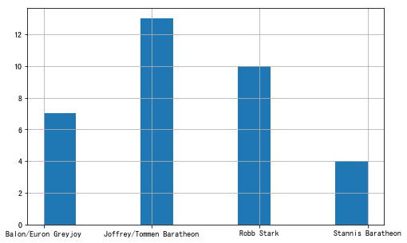

```python
clean['attacker_king'].hist(figsize=(8,5))
```

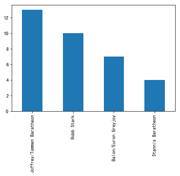

```python
clean.attacker_king.value_counts().plot(kind='bar')
```

问题2：哪一个国王获得了最多的胜利？

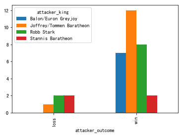

```python
clean.groupby(['attacker_outcome']).attacker_king.value_counts().unstack().plot(kind='bar')
```

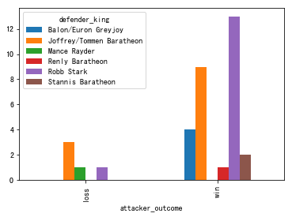

```python
clean.groupby(['attacker_outcome']).defender_king.value_counts().unstack().plot(kind='bar')
```

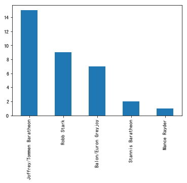

```python
clean.winner_king.value_counts().plot(kind='bar')
```

[figure not shown]

```python
clean['location'].hist(figsize=(40,10))
```

[figure not shown]

```python
clean.location.value_counts().plot(kind='bar')
```

问题4：随着时间的推进，国王发动战争的类型有什么变化？

[figure not shown]

```python
clean.groupby(['battle_type']).attacker_king.value_counts().unstack().plot(kind='bar')
```

[figure not shown]

```python
clean.groupby(['year']).battle_type.value_counts().unstack().plot(kind='bar')
```

在数据的探索性分析中，请确保你对数据分析中的关键步骤和推理过程进行了记录。你可以自己插入code cell和markdown cell来组织你的报告。

## 反思

**问题**：在你的分析和总结过程中是否存在逻辑严谨。是否有改进的空间? 你可以从下面的一些角度进行思考：

1. 数据集是否完整，包含所有想要分析的数据？
2. 在对数据进行处理的时候，你的操作（例如删除/填充缺失值）是否可能影响结论？
3. 是否还有其他变量（本数据中没有）能够对你的分析有帮助？
4. 在得出结论时，你是否混淆了相关性和因果性？

**答案**：我删除了一些不在讨论范围内的列，将NaN值也删除了。 对于直方图不是很理解，为什么在问题三中 两种图标分析出的值不一样。

恭喜你完成了此项目！这只是数据分析过程的一个样本：从生成问题、整理数据、探索数据到得出结论。在数据分析(进阶)纳米学位中，你将会学到更多高级的数据分析方法和技术，如果你感兴趣的话，我们鼓励你继续学习后续的课程，掌握更多的数据分析的高级技能！

> 若想与他人分享我们的分析结果，除了向他们提供 jupyter Notebook (.ipynb) 文件的副本外，我们还可以将 Notebook 输出导出为一种甚至那些未安装 Python 的人都能打开的形式。从左上方的“文件”菜单，前往“下载为”子菜单。然后你可以选择一个可以更普遍查看的格式，例如 HTML (.html) 。你可能需要额外软件包或软件来执行这些导出。